# Clase 03

[figure not shown]

```
Tibles join, gráficos :
inner_join, left_join, right_join, full_join, semi_join, anti_join
ggplot, geom_point, facet_grid, geom_bar, stat_count, stat_summary
```

Una versión actualizada de este material en : [clase03](https://mar71n.github.io/rconr/apuntes2023/clase03.html)

```r
library(dplyr)
```

```r
library(readr)
library(ggplot2)
```

#### [Operaciones de conjuntos](https://dplyr.tidyverse.org/articles/two-table.html#set-operations)

- ```r
  library(dplyr)
  ## Operaciones de conjuntos

  # números pares <= 30
  pares <- seq(0,30, by=2)
  pares
  ```

  ```
  ##  [1]  0  2  4  6  8 10 12 14 16 18 20 22 24 26 28 30
  ```

  ```r
  # múltiplos de tres <= 30
  tres <- seq(0, 30, by=3)
  tres
  ```

  ```
  ##  [1]  0  3  6  9 12 15 18 21 24 27 30
  ```

##### *intersect*

  ```r
  # numeros pares y múltiplos de tres
  # la intersección de los dos vectores, pensados como conjuntos
  intersect(pares, tres)
  ```

  ```
  ## [1]  0  6 12 18 24 30
  ```

##### *union*

  ```r
  # numeros pares ó múltiplos de tres
  # la unión, sin repetir, de los dos vectores pensados como conjuntos
  union(pares, tres)
  ```

  ```
  ##  [1]  0  2  4  6  8 10 12 14 16 18 20 22 24 26 28 30  3  9 15 21 27
  ```

##### *setdiff*

  ```r
  # pares que no son múltiplo de tres
  setdiff(pares, tres)
  ```

  ```
  ##  [1]  2  4  8 10 14 16 20 22 26 28
  ```

  ```r
  # múltiplos de tres que no son pares
  setdiff(tres, pares)
  ```

  ```
  ## [1]  3  9 15 21 27
  ```

#### [Uniones de transformación](https://dplyr.tidyverse.org/reference/mutate-joins.html)

- ```r
  ### Uniones

  x <- tribble(
    ~A, ~B, ~C,
    #--|--|---
    "a", "t", 1,
    "b", "u", 2,
    "c", "v", 3
  )

  x
  ```

  ```
  ## # A tibble: 3 × 3
  ##   A     B         C
  ##   <chr> <chr> <dbl>
  ## 1 a     t         1
  ## 2 b     u         2
  ## 3 c     v         3
  ```

  ```r
  y <- tribble( ~A, ~B, ~D, "a", "t", 3, "b", "u", 2, "d", "w", 1)

  y
  ```

  ```
  ## # A tibble: 3 × 3
  ##   A     B         D
  ##   <chr> <chr> <dbl>
  ## 1 a     t         3
  ## 2 b     u         2
  ## 3 d     w         1
  ```

  ```r
  ## Uniones de transformación
  # Agregan columnas de y a x. Según haya coincidencias en las claves de unión.
  ```

##### *inner_join*

- ```r
  # Solo las filas donde las claves coinciden
  inner_join(x, y)
  ```

  ```
  ## # A tibble: 2 × 4
  ##   A     B         C     D
  ##   <chr> <chr> <dbl> <dbl>
  ## 1 a     t         1     3
  ## 2 b     u         2     2
  ```

##### *left_join*

- ```r
  # todas las filas de x
  left_join(x, y)
  ```

  ```
  ## # A tibble: 3 × 4
  ##   A     B         C     D
  ##   <chr> <chr> <dbl> <dbl>
  ## 1 a     t         1     3
  ## 2 b     u         2     2
  ## 3 c     v         3    NA
  ```

##### *right_join*

- ```r
  # todas las filas de y
  right_join(x, y)
  ```

  ```
  ## # A tibble: 3 × 4
  ##   A     B         C     D
  ##   <chr> <chr> <dbl> <dbl>
  ## 1 a     t         1     3
  ## 2 b     u         2     2
  ## 3 d     w        NA     1
  ```

##### *full_join*

- ```r
  # todas las observaciones que están en x o en y
  full_join(x, y)
  ```

  ```
  ## # A tibble: 4 × 4
  ##   A     B         C     D
  ##   <chr> <chr> <dbl> <dbl>
  ## 1 a     t         1     3
  ## 2 b     u         2     2
  ## 3 c     v         3    NA
  ## 4 d     w        NA     1
  ```

#### [Uniones de filtro](https://dplyr.tidyverse.org/reference/filter-joins.html)

- ```r
  ## Uniones de filtro

  x <- tribble( ~A, ~B, ~C, "a", "t", 1, "b", "u", 2, "c", "v", 3)

  x
  ```

  ```
  ## # A tibble: 3 × 3
  ##   A     B         C
  ##   <chr> <chr> <dbl>
  ## 1 a     t         1
  ## 2 b     u         2
  ## 3 c     v         3
  ```

  ```r
  y <- tribble( ~A, ~B, ~D, "a", "t", 3, "b", "u", 2, "d", "w", 1)

  y
  ```

  ```
  ## # A tibble: 3 × 3
  ##   A     B         D
  ##   <chr> <chr> <dbl>
  ## 1 a     t         3
  ## 2 b     u         2
  ## 3 d     w         1
  ```

##### *semi_join*

- ```r
  # todas las observaciones de x que tienen una pareja en y
  # es un sub conjunto de x
  semi_join(x, y)
  ```

  ```
  ## # A tibble: 2 × 3
  ##   A     B         C
  ##   <chr> <chr> <dbl>
  ## 1 a     t         1
  ## 2 b     u         2
  ```

  ```r
  # todas las observaciones de y que tienen una pareja en x
  # es un sub conjunto de y
  semi_join(y, x)
  ```

  ```
  ## # A tibble: 2 × 3
  ##   A     B         D
  ##   <chr> <chr> <dbl>
  ## 1 a     t         3
  ## 2 b     u         2
  ```

##### *anti_join*

- ```r
  # todas las observaciones de x que NO tienen una pareja en y
  # es un sub conjunto de x
  anti_join(x, y)
  ```

  ```
  ## # A tibble: 1 × 3
  ##   A     B         C
  ##   <chr> <chr> <dbl>
  ## 1 c     v         3
  ```

### ggplot()

#### **Completando los gráficos**

##### [¿Qué es la gramática de los gráficos?](https://ggplot2-book.org/introduction.html#what-is-the-grammar-of-graphics)

##### Un gráfico esta compuesto por los **datos** que vamos a graficar.

##### Y por **mapping**: la definición de cómo las variables de esos datos son mostrados

##### **Hay 5 componentes de mapping**:

##### Layer : colección de elementos geométricos y estadísticas.

##### geom : puntos, líneas, polígonos

##### stats : conteo, ajuste de un modelo lineal, etc

##### Scales : Asigna los valores en el espacio de datos al espacio estético.

##### Incluye el color, relleno, tamaño. También leyendas y ejes

##### Coord : Sistema de coordenadas. Por lo general cartesianas, pero puede ser polares

##### al menos un layer, creado con geom

#### [geom_text](https://ggplot2.tidyverse.org/reference/geom_text.html)

#### [labs](https://ggplot2.tidyverse.org/reference/labs.html)

```r
library(forcats)
eah2025_ind <- read_csv2("./datos/eah2025_bu_ampliada/eah2025_bu_ampliada_ind.txt")
```

```
## ℹ Using "','" as decimal and "'.'" as grouping mark. Use `read_delim()` for more control.
```

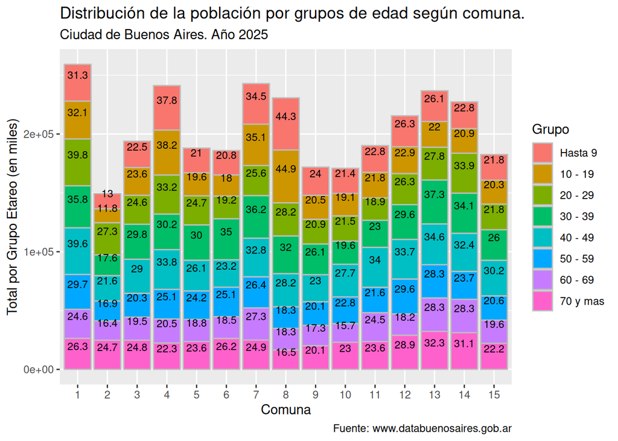

```r
pobxgrupoxcomuna <- eah2025_ind %>% arrange(edad) %>% mutate(rango = case_when( edad <= 9 ~ 'Hasta 9',
                                                           edad <= 19 ~ '10 - 19',
                                                           edad <= 29 ~ '20 - 29',
                                                           edad <= 39 ~ '30 - 39',
                                                           edad <= 49 ~ '40 - 49',
                                                           edad <= 59 ~ '50 - 59',
                                                           edad <= 69 ~ '60 - 69',
                                                           edad >= 70 ~ '70 y mas',)) %>%
  mutate(rango = as_factor(rango)) %>%
  mutate(comuna = as_factor(comuna)) %>%
  group_by(comuna) %>%
  count(rango, wt = fexp) %>%
  mutate(tot = sum(n), porc = n / sum(n)) %>% arrange(comuna, rango)


ggplot(pobxgrupoxcomuna, aes(comuna, n, fill=rango)) +
  geom_bar(stat="identity", position = "stack", colour = "grey") +
  geom_text(aes(label= round(n / 1000, 1)), vjust= -0.5, color="black", size=3, position = position_stack(vjust = 0.5)) +
  labs(
    x = "Comuna",
    y = "Total por Grupo Etareo (en miles)",
    fill = "Grupo",
    title = "Distribución de la población por grupos de edad según comuna.",
    subtitle = "Ciudad de Buenos Aires. Año 2025",
    caption = "Fuente: www.databuenosaires.gob.ar"
  )
```

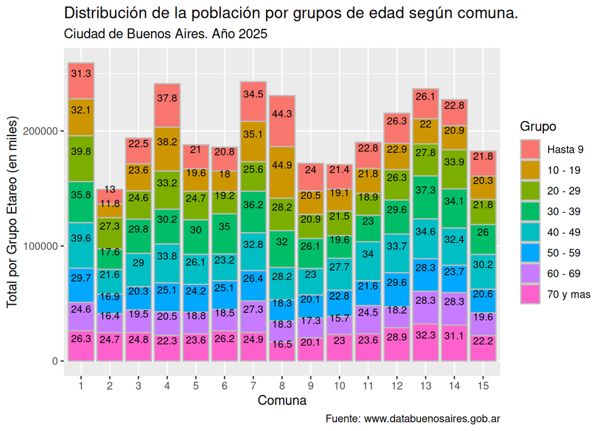

```r
# guardo el valor actual
actual <- options("scipen")
# indico que use notación fija a menos que sean mas de 10 digitos:
options(scipen=10)
ggplot(pobxgrupoxcomuna, aes(comuna, n, fill=rango)) +
  geom_bar(stat="identity", position = "stack", colour = "grey") +
  geom_text(aes(label= round(n / 1000, 1)), vjust= -0.5, color="black", size=3, position = position_stack(vjust = 0.5)) +
  labs(
    x = "Comuna",
    y = "Total por Grupo Etareo (en miles)",
    fill = "Grupo",
    title = "Distribución de la población por grupos de edad según comuna.",
    subtitle = "Ciudad de Buenos Aires. Año 2025",
    caption = "Fuente: www.databuenosaires.gob.ar"
  )
```

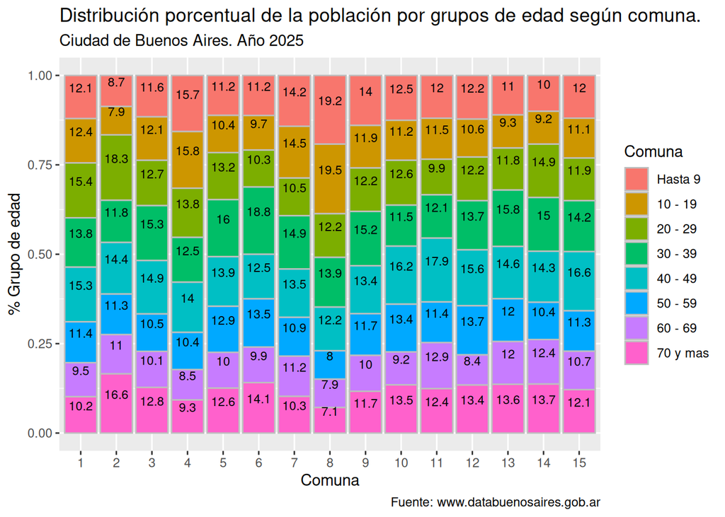

```r
# vuelvo a poner el valor anterior.
options(scipen=actual[[1]])

ggplot(pobxgrupoxcomuna, aes(comuna, porc, fill=rango)) +
  geom_bar(stat="identity", position = "fill", colour = "grey") +
  geom_text(aes(label= round(porc*100, 1)), vjust= -0.5, color="black", size=3, position = position_fill(vjust = 0.5)) +
  labs(
    x = "Comuna",
    y = "% Grupo de edad",
    fill = "Comuna",
    title = "Distribución porcentual de la población por grupos de edad según comuna.",
    subtitle = "Ciudad de Buenos Aires. Año 2025",
    caption = "Fuente: www.databuenosaires.gob.ar"
  )
```

```r
library(dplyr)
library(readr)
library(lubridate)
```

```r
library(ggplot2)
```

### Fechas en todos los formatos…

#### [*lubridate*](https://lubridate.tidyverse.org/)

```r
dmy("28FEB2021")
```

```
## [1] "2021-02-28"
```

```r
dmy("28/02/2021")
```

```
## [1] "2021-02-28"
```

```r
dmy("29/02/2021")
```

```
## [1] NA
```

```r
dmy("29/02/2020")
```

```
## [1] "2020-02-29"
```

```r
dmy_hms("28FEB2021:15:15:20")
```

```
## [1] "2021-02-28 15:15:20 UTC"
```

#### *date-time* , *date* , *time*

```r
now()
```

```
## [1] "2026-10-16 09:27:34 -03"
```

```r
today()
```

```
## [1] "2026-10-16"
```

```r
as_date(dmy_hms("28FEB2021:15:15:20"))
```

```
## [1] "2021-02-28"
```

### Grabar data frames

#### [familia **readr::write_*()**](https://readr.tidyverse.org/reference/write_delim.html)

##### Guarda un data frame en un archivo de texto donde las columnas son delimitadas por un caracter, por ejemplo “**,**” ó “**;**”

##### Las funciones **write_*()** agregan mejoras a las del tipo *write.csv()*. En primer lugar son más rápidas.

##### **delim** = el delimitador

##### en write_delim es ” ”

##### en write_csv2 es “;”

##### **append** = Si es FALSE, sobre escribe cualquier archivo existente. Si es TRUE, agrega los registros al final.

##### En ambos casos, si el archivo no existe lo crea.

##### **col_names** = Si es FALSE no se agregan los nombres de columna en la primera fila, si es TRUE sí se agregan.

##### El valor tiene que ser lo contrario de lo que se pase en append.

##### **quote** = En que casos entrecomillar los valores.

##### ‘needed’ : solo si es necesario ( cuando el valor incluye comillas, el delimitador o saltos de linea)

##### ‘all’ : entrecomillar todas las columnas

##### ‘none’ : ninguno

##### **escape** = El tipo de escape a usar cuando hay comillas en los datos.

##### ‘double’ : “”

##### ‘backslash’ : \

##### ‘none’ : ninguno

### Guardar gráficos

#### [**ggsave**](https://ggplot2.tidyverse.org/reference/ggsave.html)

### Rscript

```
>R.home() \bin\
C:\Program Files\R\R-4.2.1\bin\Rscript.exe
```

### Un script que descarga los datos y graba los gráficos

#### *crear_graficos.R* :

```
library(dplyr)
library(lubridate)
library(readr)
library(ggplot2)`
```

### Bibliografia:

#### [R para Ciencia de Datos - Cap 13 Datos relacionales](https://es.r4ds.hadley.nz/13-relational-data.html)

#### [R para Ciencia de Datos - Cap 28 Comunicar con gráficos](https://es.r4ds.hadley.nz/28-communicate-plots.html)

#### [Elegant Graphics for Data Analysis](https://ggplot2-book.org)

clase03.R

cuadro02.R

crear-cuadro-02.R

[figure not shown]